# Noise

```python
import numpy as np
import matplotlib.pyplot as plt
%matplotlib inline
```

### vectors

A vector is a row (or column depending on how you look at it) of numbers. If we want to write a literal vector in math it often is in written in brackets:

$\begin{bmatrix}1 & 2 & 3\end{bmatrix}$

If we wanna a particular matrix more often and don't wanna repeat the numbers each time we can give it a name. The name ${v}$ is a popular choice.

${v} = \begin{bmatrix}4 & 5 & 6\end{bmatrix}$

Sometimes we want to make it extra clear that we are dealing with a vector. There's multiple ways to do that but we'll use a notation like $\vec{v}$ for the remainder of this text.

#### vectors and you

The things we store into a vector *don't have* to be real numbers. They can be *imaginary* numbers as well. Besides being very elegant in their own right they are very popular because they can also be used to [parralalize](https://en.wikipedia.org/wiki/Automatic_parallelization) operations because multiple *parameters* of the problem can be computed in parallel.

We can also easily represent a vector in `python` as a `list` of numbers.

```python
v = [1,2,3] # a vector of length 3
N = len(v)  # N = 3
```

In the above case we can say the length of vector ${v}$ is equal to ${N}$ which is equal to 3.

${N} = 3$

### scalars

A vector of length one is basically a number. We can also think of it as a direction in a one-dimensional space.

This is also sometimes called a *scalar* which basically is a something that you can multiply with some vector to get a new vector. Note that all real numbers are valid scalars but not every scalar has to be a real number.

### matrices

Between matrices, vectors and scalars, the matrix is actually the most general. A vector is a $1 \times {N}$ matrix and a scalar is a $1 \times 1$ matrix. They have awesome notation as well, take, for example, this matrix ${M}$:

$ M = \begin{bmatrix}1 & 2 & 3\\4 & 5 & 6\end{bmatrix}$

It might be more easy to see now how a vector is just a matrix with one dimension.

$v = \begin{bmatrix}1 & 2 & 3\end{bmatrix}$

Or as a column matrix:

$v = \begin{bmatrix}1\\2\\3\end{bmatrix}$

And a scalar can be just:

$v = \begin{bmatrix}{x}\end{bmatrix}$

Which is a 1x1 vector, a 1x1 matrix and basically equivalent to any real number ${x}$.

We can observe:

- Every scalar is a vector (a 1x1 vector)
- Every vector is a matrix (a 1xN matrix)
- Not every vector is a scalar
- Not every matrix is a vector

### noise functions

I'm not sure if there's an official definition for a *noise function* but for our intends and purposes it's a function $f$ that takes a vector $\vec{x}$ of length ${N}$ and returns a *floating point* (decimal) number ${y}$ in the range `0` to `1`.

$y = f \vec{x}$ where $0 \le {y} \le 1.0$ and ${N} \gt 0$

Now that we have defined what a noise function is we can actually define one:

$y = f x = 0.30$

There are two things to note:

- We got rid of $\vec{x}$ and replaced it with just ${x}$ what's up with that?
- Our noise function $f$ is defined as a constant; how noisy is it?

We're gonna replace $\vec{x}$ with ${x}$ for now because it just makes things more simple. If we can make this work for one dimension (where the input for the noise function is basically just a ${x}$ coördinate) we should be able make it work in ${N} dimensions as well.

[figure not shown]

```python
def seed(n, max_vertices=10):
    global r
    np.random.seed(n)
    r = [np.random.ranf() for i in range(max_vertices)]

seed(0)
x = np.linspace(0, len(r) - 1, len(r))
plt.plot(x, r, "ro", label="seed = 0")

seed(1)
plt.plot(x, r, "ro", label="seed = 1")

seed(2)
plt.plot(x, r, "go", label="seed = 2")

plt.legend()
```

```python
def lerp(v0, v1, a):
    return (1.0 - a) * v0 + v1 * a
```

The `lerp` function is the [linear interpolation](https://en.wikipedia.org/wiki/Linear_interpolation) function.

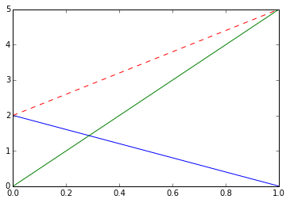

```python
c1 = lambda v, a: (1.0 - a) * v
c2 = lambda v, a: v * a
x = np.linspace(0, 1.0, 100)
y1 = [c1(2, x) for x in x]
y2 = [c2(5, x) for x in x]
y3 = [y1 + y2 for y1, y2 in zip(y1, y2)]
plt.plot(x, y1)
plt.plot(x, y2)
plt.plot(x, y3, '--')
```

The `scurve3` and `scurve5` functions are examples of [smoothstep](https://en.wikipedia.org/wiki/Smoothstep) functions.

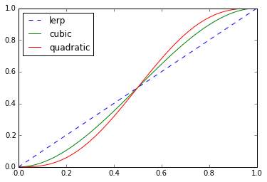

```python
def scurve3(a):
    return a * a * (3.0 - 2.0 * a)

def scurve5(a):
    a3 = a * a * a
    a4 = a3 * a
    a5 = a4 * a
    return (6.0 * a5) - (15.0 * a4) + (10.0 * a3)

x = np.linspace(0, 1.0, 100)
y1 = lerp(0.0, 1.0, x)
y2 = scurve3(x)
y3 = scurve5(x)
plt.axis([0, 1.0, 0, 1])
plt.plot(x, y1, "--", label="lerp")
plt.plot(x, y2, label="cubic")
plt.plot(x, y3, label="quadratic")
plt.legend(loc=2)
```

The `curve` function uses the $\cos$ from 0 to $\pi$ to produce a smooth curve.

```python
def curve(a):
    return (1.0 - np.cos(a * np.pi)) * 0.5
```

Note that it produces almost exactly the same result as the `scurve3` smoothstep function.

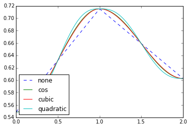

```python
def noise1(x, c=lambda a: a):
    global r
    xi = int(x)
    xmin = xi % MAX_VERTICES
    xmax = 0 if xmin == (MAX_VERTICES - 1) else xmin + 1
    t = x - xi
    return lerp(r[xmin], r[xmax], c(t))

x = np.linspace(0, 2.0, 100)
y1 = [noise1(x) for x in x]
y2 = [noise1(x, curve) for x in x]
y3 = [noise1(x, scurve3) for x in x]
y4 = [noise1(x, scurve5) for x in x]
plt.plot(x, y1, "--", label="none")
plt.plot(x, y2, label="cos")
plt.plot(x, y3, label="cubic")
plt.plot(x, y4, label="quadratic")
plt.legend(loc=3)
```

We can scale the noise by multiplying the input(s).

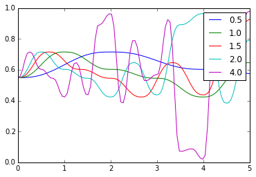

```python
seed(0, max_vertices=1024)
get_noise = lambda x, f: noise1(x * f, scurve5)
x = np.linspace(0, 5.0, 100)
frequencies = [0.5, 1.0, 1.5, 2.0, 4.0]
graphs = [[get_noise(x, f) for x in x] for f in frequencies]
for i in range(len(frequencies)):
    f = frequencies[i]
    plt.plot(x, graphs[i], label = str(f))
plt.legend()
```